# Telecom Customer Retention | Joseph Thiongo

#1. DEFINING THE QUESTION

#a) Specifying the Data Analysis Question

The management would like to get your assistance in understanding the current subscribed customers. Your recommendations informed by your analysis will help them make informed decisions on effective customer retention programs.

To put it simply, the task is to understand current customers in order to understand how to retain them.

#b) Defining the Metric for Success

The solution will have satisfied the research question when you can identify the factors that contribute to customer churn.

#c) Understanding the context

MTN Telecom offers mobile and internet services to its customers. These services include phone, multiple lines, internet, online security, online backup, device protection, tech support, and streaming TV and movies.

You have been provided with the current customer data. Since you will be working towards a descriptive report than a predictive one, you decide to think critically of the kind of questions that would help you craft customer retention programs. You then later use the given data set to answer your questions but before you start, you reading, explore, clean and visualize your dataset.

#d) Recording the Experimental Design

The steps to be taken include:

1.Load dataset and preview its summarized information to get a feel of what you will be working with. 2.Carry out data cleaning. 3.Carry out data analysis. 4.Interpret results. 5.Provide recommendations based on results of analysis. 6.Challenge your solution.

#e) Data Relevance

For now, the data we have contains churn data which will be critical for our research specific analysis.

#2. DATA CLEANING AND PREPARATION

#a)install and load libraries

```r
install.packages("tidyverse")
library(tidyverse)
```

#b)Import the dataset

```r
customer_df <- read_csv("https://bit.ly/2ZlpzjF")
head(customer_df)
```

| customerID | GENDER | SeniorCitizen | PARTNER | Dependents | tenure | PhoneService | MultipleLines | InternetService | OnlineSecurity | OnlineBackup | DeviceProtection | TECHSUPPORT | StreamingTV | StreamingMovies | Contract | PaperlessBilling | PaymentMethod | MonthlyCharges | TotalCharges | Churn |
| --- | --- | --- | --- | --- | --- | --- | --- | --- | --- | --- | --- | --- | --- | --- | --- | --- | --- | --- | --- | --- |
| 7590-VHVEG | Female | 0 | Yes | No | 1 | No | No phone service | DSL | No | Yes | No | No | No | No | Month-to-month | Yes | Electronic check | 29.85 | 29.85 | No |
| 5575-GNVDE | Male | 0 | No | No | 34 | Yes | No | DSL | Yes | No | Yes | No | No | No | One year | No | Mailed check | 56.95 | 1889.50 | No |
| 3668-QPYBK | Male | 0 | No | No | 2 | Yes | No | DSL | Yes | Yes | No | No | No | No | Month-to-month | Yes | Mailed check | 53.85 | 108.15 | Yes |
| 7795-CFOCW | Male | 0 | No | No | 45 | No | No phone service | DSL | Yes | No | Yes | Yes | No | No | One year | No | Bank transfer (automatic) | 42.30 | 1840.75 | No |
| 9237-HQITU | Female | 0 | No | No | 2 | Yes | No | Fiber optic | No | No | No | No | No | No | Month-to-month | Yes | Electronic check | 70.70 | 151.65 | Yes |
| 9305-CDSKC | Female | 0 | No | No | 8 | Yes | Yes | Fiber optic | No | No | Yes | No | Yes | Yes | Month-to-month | Yes | Electronic check | 99.65 | 820.50 | Yes |

#c)Getting dataset shape

```r
dim(customer_df)
```

```
## [1] 7050   21
```

#d)Checking for duplicates and drop them if any

```r
#customer_df[duplicated(customer_df), ] ..7 duplicate records found
cust1_df <- customer_df %>% distinct()
dim(cust1_df)
```

```
## [1] 7043   21
```

#e)Checking for missing values and drop them if any

```r
colSums(is.na(cust1_df))
```

```
##       customerID           GENDER    SeniorCitizen          PARTNER
##                0                1                3               12
##       Dependents           tenure     PhoneService    MultipleLines
##               10               11               15               17
##  InternetService   OnlineSecurity     OnlineBackup DeviceProtection
##               16               16               15               14
##      TECHSUPPORT      StreamingTV  StreamingMovies         Contract
##               13               13               12               12
## PaperlessBilling    PaymentMethod   MonthlyCharges     TotalCharges
##               12               12               12               23
##            Churn
##               12
```

```r
cust1_df <- na.omit(cust1_df)
dim(cust1_df)
```

```
## [1] 7003   21
```

#f)Properly formatting columns to lowercase

```r
names(cust1_df) <- trimws(names(cust1_df), which = c("both"))
names(cust1_df) <- tolower(names(cust1_df))
names(cust1_df)
```

```
##  [1] "customerid"       "gender"           "seniorcitizen"    "partner"
##  [5] "dependents"       "tenure"           "phoneservice"     "multiplelines"
##  [9] "internetservice"  "onlinesecurity"   "onlinebackup"     "deviceprotection"
## [13] "techsupport"      "streamingtv"      "streamingmovies"  "contract"
## [17] "paperlessbilling" "paymentmethod"    "monthlycharges"   "totalcharges"
## [21] "churn"
```

#g)previewing the number of unique values in each column

```r
unique(cust1_df)
```

| customerid | gender | seniorcitizen | partner | dependents | tenure | phoneservice | multiplelines | internetservice | onlinesecurity | onlinebackup | deviceprotection | techsupport | streamingtv | streamingmovies | contract | paperlessbilling | paymentmethod | monthlycharges | totalcharges | churn |
| --- | --- | --- | --- | --- | --- | --- | --- | --- | --- | --- | --- | --- | --- | --- | --- | --- | --- | --- | --- | --- |
| 7590-VHVEG | Female | 0 | Yes | No | 1 | No | No phone service | DSL | No | Yes | No | No | No | No | Month-to-month | Yes | Electronic check | 29.85 | 29.85 | No |
| 5575-GNVDE | Male | 0 | No | No | 34 | Yes | No | DSL | Yes | No | Yes | No | No | No | One year | No | Mailed check | 56.95 | 1889.50 | No |
| 3668-QPYBK | Male | 0 | No | No | 2 | Yes | No | DSL | Yes | Yes | No | No | No | No | Month-to-month | Yes | Mailed check | 53.85 | 108.15 | Yes |
| 7795-CFOCW | Male | 0 | No | No | 45 | No | No phone service | DSL | Yes | No | Yes | Yes | No | No | One year | No | Bank transfer (automatic) | 42.30 | 1840.75 | No |
| 9237-HQITU | Female | 0 | No | No | 2 | Yes | No | Fiber optic | No | No | No | No | No | No | Month-to-month | Yes | Electronic check | 70.70 | 151.65 | Yes |
| 9305-CDSKC | Female | 0 | No | No | 8 | Yes | Yes | Fiber optic | No | No | Yes | No | Yes | Yes | Month-to-month | Yes | Electronic check | 99.65 | 820.50 | Yes |
| 1452-KIOVK | Male | 0 | No | Yes | 22 | Yes | Yes | Fiber optic | No | Yes | No | No | Yes | No | Month-to-month | Yes | Credit card (automatic) | 89.10 | 1949.40 | No |
| 6713-OKOMC | Female | 0 | No | No | 10 | No | No phone service | DSL | Yes | No | No | No | No | No | Month-to-month | No | Mailed check | 29.75 | 301.90 | No |
| 7892-POOKP | Female | 0 | Yes | No | 28 | Yes | Yes | Fiber optic | No | No | Yes | Yes | Yes | Yes | Month-to-month | Yes | Electronic check | 104.80 | 3046.05 | Yes |
| 6388-TABGU | Male | 0 | No | Yes | 62 | Yes | No | DSL | Yes | Yes | No | No | No | No | One year | No | Bank transfer (automatic) | 56.15 | 3487.95 | No |

[output cut: 6993 more lines]

#h)Checking the datatypes

```r
glimpse(cust1_df)
```

```
## Rows: 7,003
## Columns: 21
## $ customerid       <chr> "7590-VHVEG", "5575-GNVDE", "3668-QPYBK", "7795-CFOCW…
## $ gender           <chr> "Female", "Male", "Male", "Male", "Female", "Female",…
## $ seniorcitizen    <dbl> 0, 0, 0, 0, 0, 0, 0, 0, 0, 0, 0, 0, 0, 0, 0, 0, 0, 0,…
## $ partner          <chr> "Yes", "No", "No", "No", "No", "No", "No", "No", "Yes…
## $ dependents       <chr> "No", "No", "No", "No", "No", "No", "Yes", "No", "No"…
## $ tenure           <dbl> 1, 34, 2, 45, 2, 8, 22, 10, 28, 62, 13, 16, 58, 49, 2…
## $ phoneservice     <chr> "No", "Yes", "Yes", "No", "Yes", "Yes", "Yes", "No", …
## $ multiplelines    <chr> "No phone service", "No", "No", "No phone service", "…
## $ internetservice  <chr> "DSL", "DSL", "DSL", "DSL", "Fiber optic", "Fiber opt…
## $ onlinesecurity   <chr> "No", "Yes", "Yes", "Yes", "No", "No", "No", "Yes", "…
## $ onlinebackup     <chr> "Yes", "No", "Yes", "No", "No", "No", "Yes", "No", "N…
## $ deviceprotection <chr> "No", "Yes", "No", "Yes", "No", "Yes", "No", "No", "Y…
## $ techsupport      <chr> "No", "No", "No", "Yes", "No", "No", "No", "No", "Yes…
## $ streamingtv      <chr> "No", "No", "No", "No", "No", "Yes", "Yes", "No", "Ye…
## $ streamingmovies  <chr> "No", "No", "No", "No", "No", "Yes", "No", "No", "Yes…
## $ contract         <chr> "Month-to-month", "One year", "Month-to-month", "One …
## $ paperlessbilling <chr> "Yes", "No", "Yes", "No", "Yes", "Yes", "Yes", "No", …
## $ paymentmethod    <chr> "Electronic check", "Mailed check", "Mailed check", "…
## $ monthlycharges   <dbl> 29.85, 56.95, 53.85, 42.30, 70.70, 99.65, 89.10, 29.7…
## $ totalcharges     <dbl> 29.85, 1889.50, 108.15, 1840.75, 151.65, 820.50, 1949…
## $ churn            <chr> "No", "No", "Yes", "No", "Yes", "Yes", "No", "No", "Y…
```

```r
str(cust1_df)
```

```
## tibble [7,003 × 21] (S3: tbl_df/tbl/data.frame)
##  $ customerid      : chr [1:7003] "7590-VHVEG" "5575-GNVDE" "3668-QPYBK" "7795-CFOCW" ...
##  $ gender          : chr [1:7003] "Female" "Male" "Male" "Male" ...
##  $ seniorcitizen   : num [1:7003] 0 0 0 0 0 0 0 0 0 0 ...
##  $ partner         : chr [1:7003] "Yes" "No" "No" "No" ...
##  $ dependents      : chr [1:7003] "No" "No" "No" "No" ...
##  $ tenure          : num [1:7003] 1 34 2 45 2 8 22 10 28 62 ...
##  $ phoneservice    : chr [1:7003] "No" "Yes" "Yes" "No" ...
##  $ multiplelines   : chr [1:7003] "No phone service" "No" "No" "No phone service" ...
##  $ internetservice : chr [1:7003] "DSL" "DSL" "DSL" "DSL" ...
##  $ onlinesecurity  : chr [1:7003] "No" "Yes" "Yes" "Yes" ...
##  $ onlinebackup    : chr [1:7003] "Yes" "No" "Yes" "No" ...
##  $ deviceprotection: chr [1:7003] "No" "Yes" "No" "Yes" ...
##  $ techsupport     : chr [1:7003] "No" "No" "No" "Yes" ...
##  $ streamingtv     : chr [1:7003] "No" "No" "No" "No" ...
##  $ streamingmovies : chr [1:7003] "No" "No" "No" "No" ...
##  $ contract        : chr [1:7003] "Month-to-month" "One year" "Month-to-month" "One year" ...
##  $ paperlessbilling: chr [1:7003] "Yes" "No" "Yes" "No" ...
##  $ paymentmethod   : chr [1:7003] "Electronic check" "Mailed check" "Mailed check" "Bank transfer (automatic)" ...
##  $ monthlycharges  : num [1:7003] 29.9 57 53.9 42.3 70.7 ...
##  $ totalcharges    : num [1:7003] 29.9 1889.5 108.2 1840.8 151.7 ...
##  $ churn           : chr [1:7003] "No" "No" "Yes" "No" ...
##  - attr(*, "na.action")= 'omit' Named int [1:40] 489 754 937 960 961 976 983 1083 1188 1199 ...
##   ..- attr(*, "names")= chr [1:40] "489" "754" "937" "960" ...
```

#i)create a loop to preview the unique values of variables

```r
cols1 <- names(cust1_df)
#cols1
rem1 <- c('customerid', 'tenure', 'monthlycharges', 'totalcharges')
cols1[- c(1,6,19,20)]
```

```
##  [1] "gender"           "seniorcitizen"    "partner"          "dependents"
##  [5] "phoneservice"     "multiplelines"    "internetservice"  "onlinesecurity"
##  [9] "onlinebackup"     "deviceprotection" "techsupport"      "streamingtv"
## [13] "streamingmovies"  "contract"         "paperlessbilling" "paymentmethod"
## [17] "churn"
```

```r
out1 <- "\nShowing unique values of variable:"

for (x in cols1){
   cat(out1,x)
   #unique(cust1_df[[toString(x)]])
}
```

```
##
## Showing unique values of variable: customerid
## Showing unique values of variable: gender
## Showing unique values of variable: seniorcitizen
## Showing unique values of variable: partner
## Showing unique values of variable: dependents
## Showing unique values of variable: tenure
## Showing unique values of variable: phoneservice
## Showing unique values of variable: multiplelines
## Showing unique values of variable: internetservice
## Showing unique values of variable: onlinesecurity
## Showing unique values of variable: onlinebackup
## Showing unique values of variable: deviceprotection
## Showing unique values of variable: techsupport
## Showing unique values of variable: streamingtv
## Showing unique values of variable: streamingmovies
## Showing unique values of variable: contract
## Showing unique values of variable: paperlessbilling
## Showing unique values of variable: paymentmethod
## Showing unique values of variable: monthlycharges
## Showing unique values of variable: totalcharges
## Showing unique values of variable: churn
```

#j)resolving the issues in the ‘senior_citizen’ variable

```r
cust1_df$seniorcitizen[cust1_df$seniorcitizen == 0] <- 'No'
cust1_df$seniorcitizen[cust1_df$seniorcitizen == 1] <- 'Yes'
head(cust1_df)
```

| customerid | gender | seniorcitizen | partner | dependents | tenure | phoneservice | multiplelines | internetservice | onlinesecurity | onlinebackup | deviceprotection | techsupport | streamingtv | streamingmovies | contract | paperlessbilling | paymentmethod | monthlycharges | totalcharges | churn |
| --- | --- | --- | --- | --- | --- | --- | --- | --- | --- | --- | --- | --- | --- | --- | --- | --- | --- | --- | --- | --- |
| 7590-VHVEG | Female | No | Yes | No | 1 | No | No phone service | DSL | No | Yes | No | No | No | No | Month-to-month | Yes | Electronic check | 29.85 | 29.85 | No |
| 5575-GNVDE | Male | No | No | No | 34 | Yes | No | DSL | Yes | No | Yes | No | No | No | One year | No | Mailed check | 56.95 | 1889.50 | No |
| 3668-QPYBK | Male | No | No | No | 2 | Yes | No | DSL | Yes | Yes | No | No | No | No | Month-to-month | Yes | Mailed check | 53.85 | 108.15 | Yes |
| 7795-CFOCW | Male | No | No | No | 45 | No | No phone service | DSL | Yes | No | Yes | Yes | No | No | One year | No | Bank transfer (automatic) | 42.30 | 1840.75 | No |
| 9237-HQITU | Female | No | No | No | 2 | Yes | No | Fiber optic | No | No | No | No | No | No | Month-to-month | Yes | Electronic check | 70.70 | 151.65 | Yes |
| 9305-CDSKC | Female | No | No | No | 8 | Yes | Yes | Fiber optic | No | No | Yes | No | Yes | Yes | Month-to-month | Yes | Electronic check | 99.65 | 820.50 | Yes |

```r
#unique(cust1_df$seniorcitizen)
```

#k)# resolving the issues in the ‘payment_method’ variable

```r
cust1_df$paymentmethod[cust1_df$paymentmethod == "Mailed checkkk"] <- "Mailed check"
cust1_df$paymentmethod[cust1_df$paymentmethod == "Electronic checkk"] <- "Electronic check"
#head(cust1_df)
unique(cust1_df$paymentmethod)
```

```
## [1] "Electronic check"          "Mailed check"
## [3] "Bank transfer (automatic)" "Credit card (automatic)"
```

#l)# visual distribution of the outliers using a box plot for the ‘tenure’, ‘monthly_charges’ and ‘total_charges’

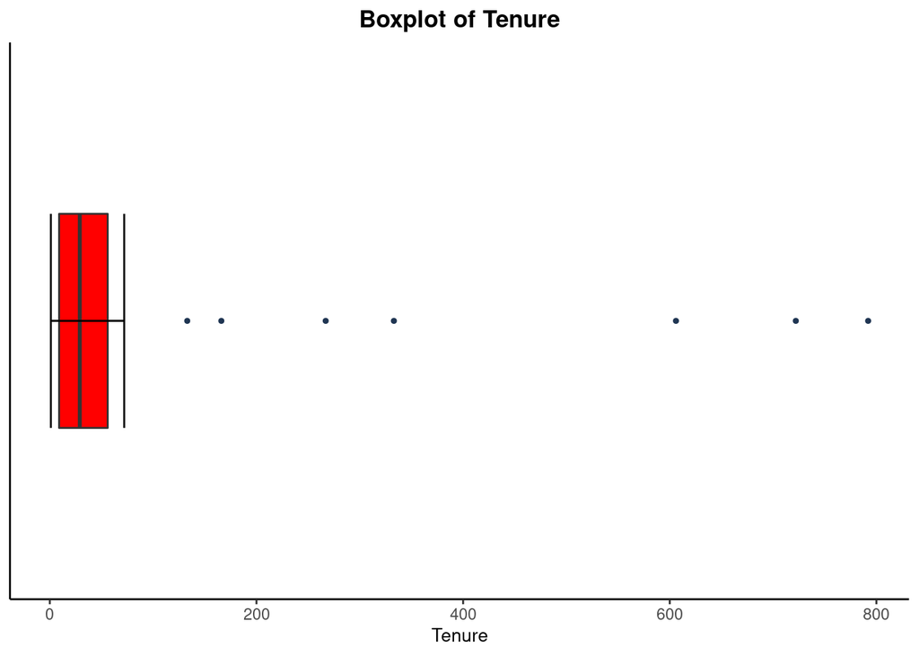

```r
# Plotting the Tenure chart
ggplot(cust1_df, aes(y=tenure)) +
  geom_boxplot(fill = "red", outlier.colour = "#1F3552", outlier.shape = 20) +
  stat_boxplot(geom ="errorbar") +
  scale_x_discrete() +
  labs(
    title = "Boxplot of Tenure",
    y = "Tenure"
  ) + theme_classic() +
  theme(
    plot.title = element_text(size = 13, face = "bold", hjust = 0.5),
    axis.title.x = element_text(size = 10),
  ) + coord_flip()
```

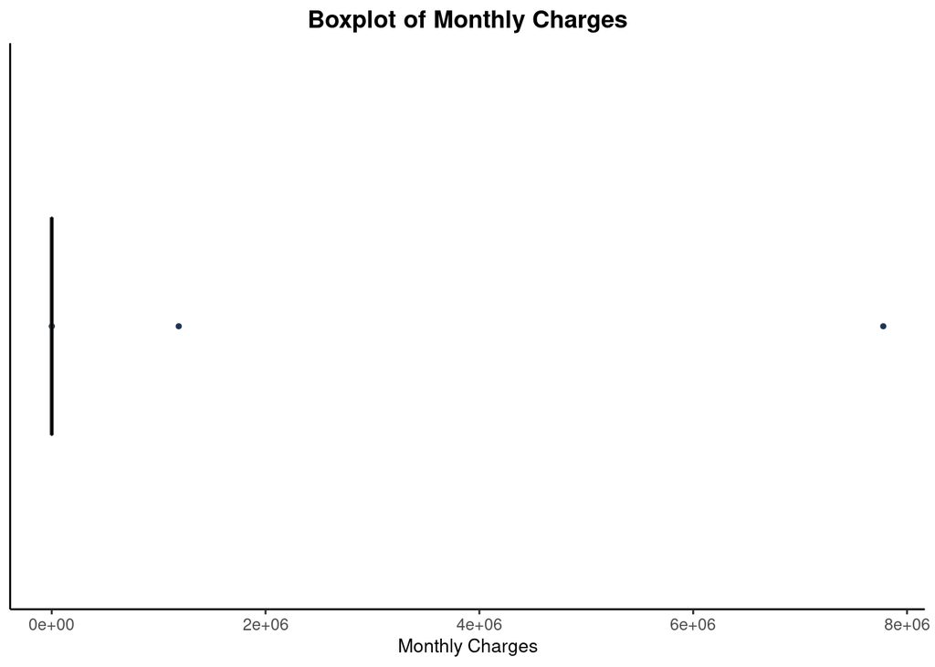

```r
# Plotting the Month charges chart
ggplot(cust1_df, aes(y=monthlycharges)) +
  geom_boxplot(fill = "red", outlier.colour = "#1F3552", outlier.shape = 20) +
  stat_boxplot(geom ="errorbar") +
  scale_x_discrete() +
  labs(
    title = "Boxplot of Monthly Charges",
    y = "Monthly Charges"
  ) + theme_classic() +
  theme(
    plot.title = element_text(size = 13, face = "bold", hjust = 0.5),
    axis.title.x = element_text(size = 10),
  ) + coord_flip()
```

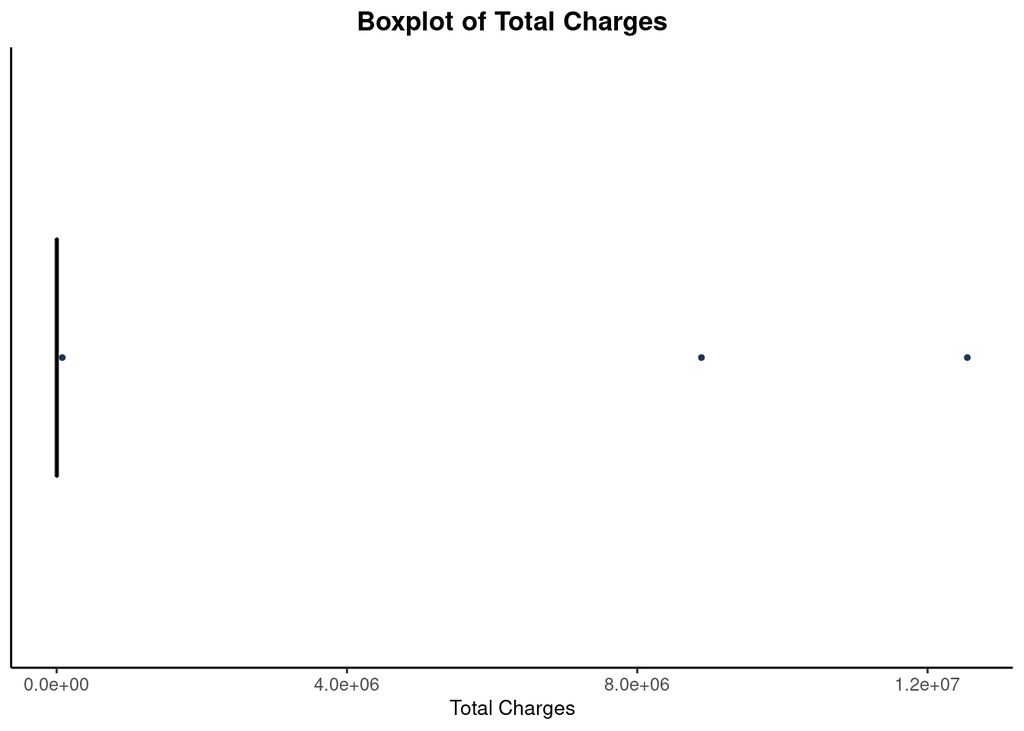

```r
# Plotting the total charges chart
ggplot(cust1_df, aes(y=totalcharges)) +
  geom_boxplot(fill = "red", outlier.colour = "#1F3552", outlier.shape = 20) +
  stat_boxplot(geom ="errorbar") +
  scale_x_discrete() +
  labs(
    title = "Boxplot of Total Charges",
    y = "Total Charges"
  ) + theme_classic() +
  theme(
    plot.title = element_text(size = 13, face = "bold", hjust = 0.5),
    axis.title.x = element_text(size = 10),
  ) + coord_flip()
```

We can see that there are several outliers in the ‘tenure’, ‘monthly_charges’, and ‘total_charges’ variables. We can remove them using the IQR method.

#m)Calculate IQRs and remove outliers

```r
outliers <- function(x) {

  Q1 <- quantile(x, probs=.25)
  Q3 <- quantile(x, probs=.75)
  iqr = Q3-Q1

 upper_limit = Q3 + (iqr*1.5)
 lower_limit = Q1 - (iqr*1.5)

 x > upper_limit | x < lower_limit
}

remove_outliers <- function(df, cols = names(df)) {
  for (col in cols) {
    df <- df[!outliers(df[[col]]),]
  }
  df
}

cust1_NO <- remove_outliers(cust1_df, c('tenure', 'monthlycharges', 'totalcharges'))
dim(cust1_NO)
```

```
## [1] 6990   21
```

We have cleaned our data and are now ready to analyze it.

#3. DATA ANALYSIS Since our research question requires us to focus on how we can retain customers, the main variable to work with is the “churn” variable.

#i) Research-specific Analysis What percentage of customers from our dataset churned?

```r
clean_df <- cust1_NO
#dim(clean_df)

library(sqldf)
```

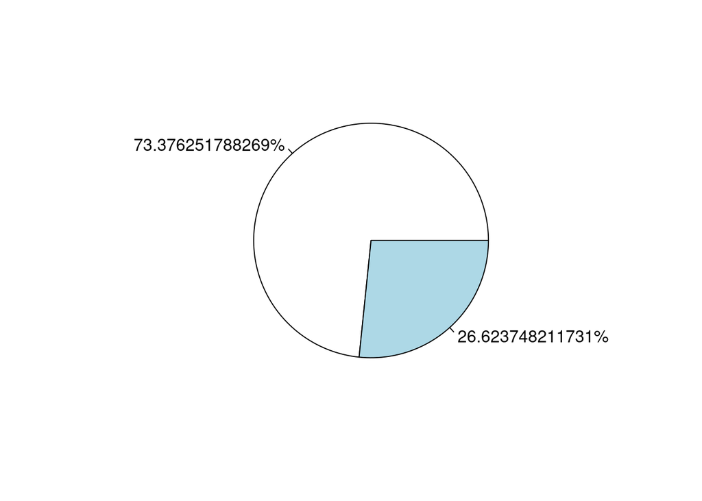

```r
yesno_df <- sqldf("select
              sum(Churn = 'No') as No,
              sum(Churn = 'Yes') as Yes
       from clean_df
       ")

yesno_df$Total <- yesno_df$No + yesno_df$Yes

test <- table(clean_df$churn)
#yesno_df

pie(test,labels = paste0(test/yesno_df$Total * 100, "%"))
```

We see that the majority of the customers in this dataset, 73% of the customers are still subscribed to MTN while 26.6% of the customers churned.

#b) let’s now make a comparison betweeen male and female subscribers by plotting the distribution of churn by gender

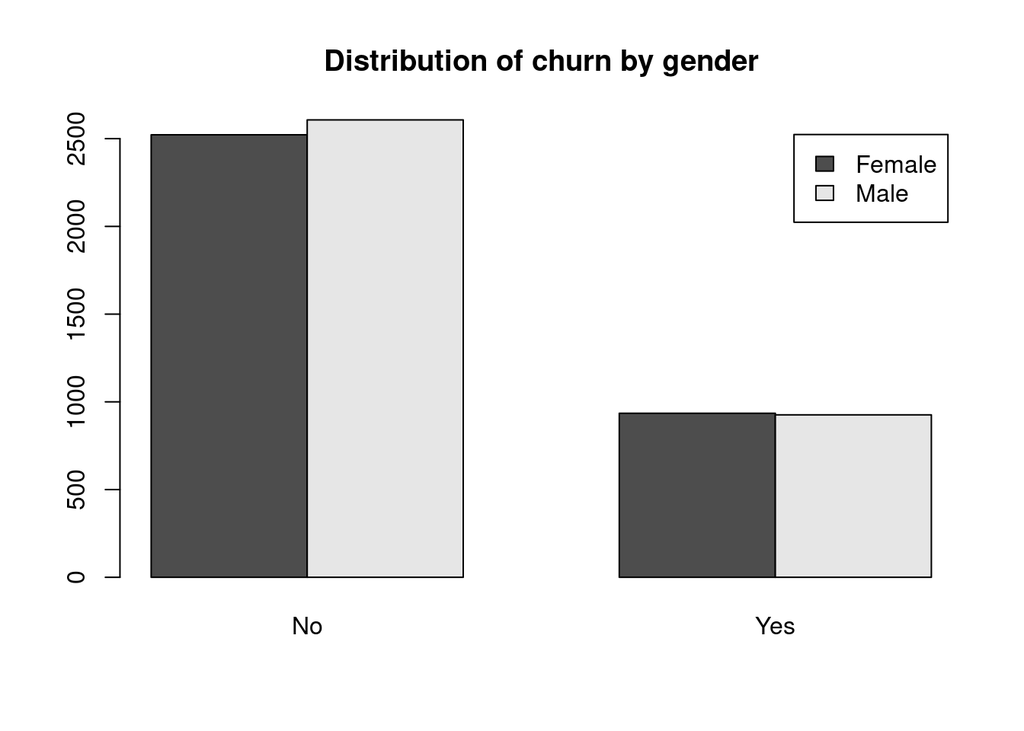

```r
tbl <- with(clean_df, table(gender, churn))

barplot(tbl, beside = TRUE, legend = TRUE, main = "Distribution of churn by gender")
```

OBSERVATION: Number of men who churned practically equal to number of women who churned

#c) we investigate the distribution of churn by senior citizen and recording our observations plotting the distribution of churn by senior citizen below

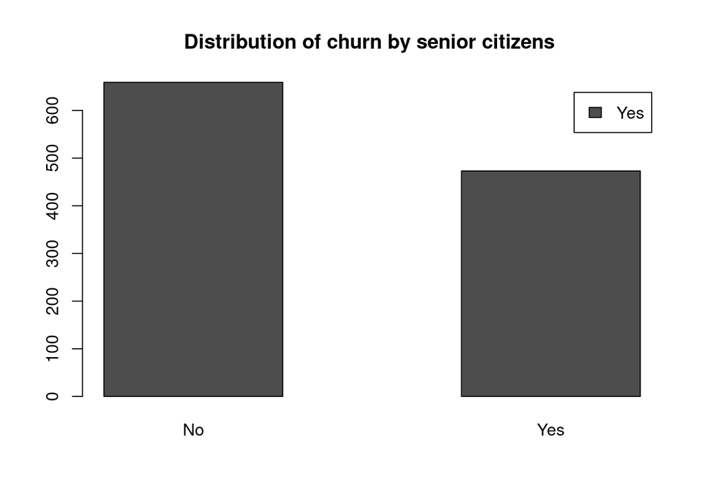

```r
senior_df <- sqldf("select
              seniorcitizen,
              churn
            from clean_df where seniorcitizen='Yes'
       ")
tbl2 <- with(senior_df, table(seniorcitizen, churn))

barplot(tbl2, beside = TRUE, legend = TRUE, main = "Distribution of churn by senior citizens ")
```

OBSERVATION: Fewer senior citizens churned than those who remained loyal customers

#d) plotting the distribution of churn by partner and recording our observations. Let’s plot the distribution of churn by partner

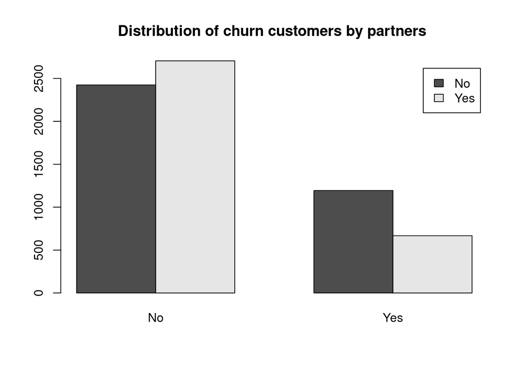

```r
tbl3 <- with(clean_df, table(partner, churn))

barplot(tbl3, beside = TRUE, legend = TRUE, main = "Distribution of churn customers by partners ")
```

OBSERVATION: Number of churns among customers with partners was less than among customers without partners

#e) plotting the distribution of churn by dependents and then record your observations.

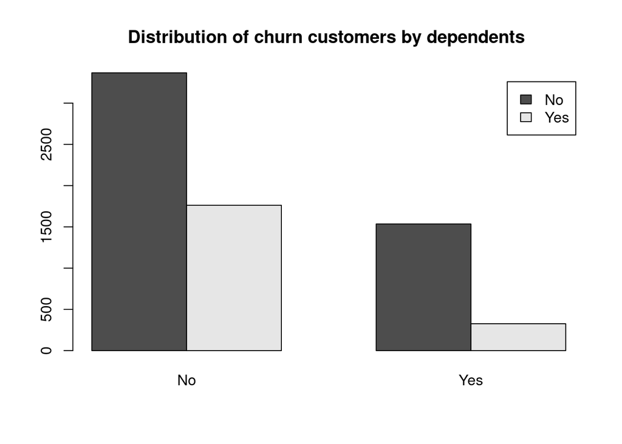

```r
tbl5 <- with(clean_df, table(dependents, churn))

barplot(tbl5, beside = TRUE, legend = TRUE, main = "Distribution of churn customers by dependents ")
```

OBSERVATION:: customers with no dependents are the higher demographic in retained customer base.

#f) plotting the distribution of churn by phone service then recording your observations.

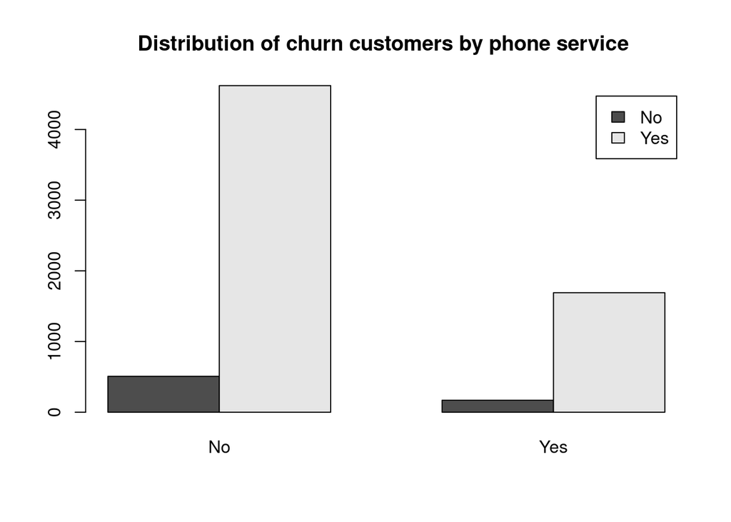

```r
tbl7 <- with(clean_df, table(phoneservice, churn))

barplot(tbl7, beside = TRUE, legend = TRUE, main = "Distribution of churn customers by phone service ")
```

#g) plotting the distribution of churn by multiple lines and record our observations.

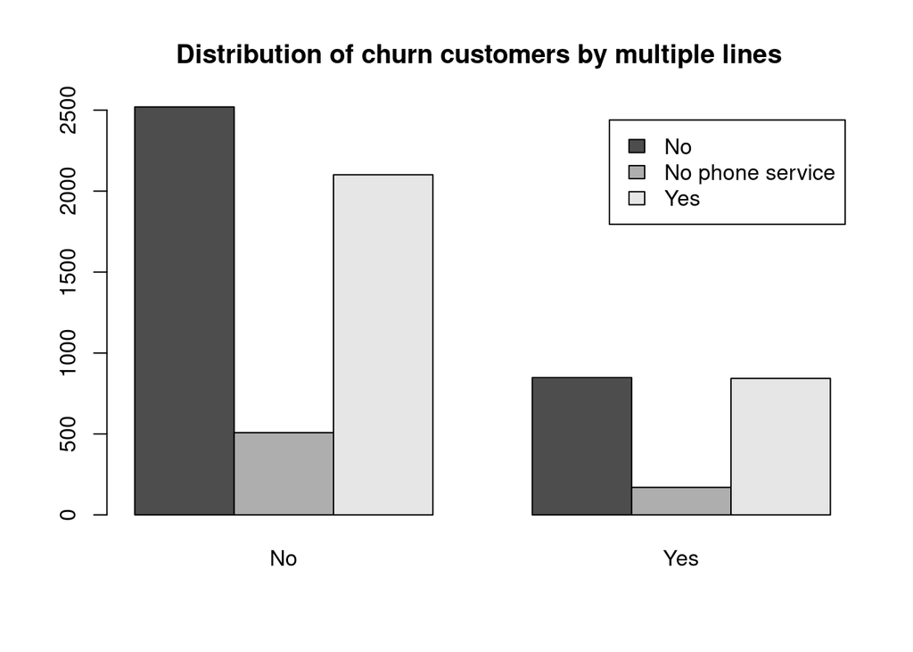

```r
tbl9 <- with(clean_df, table(multiplelines, churn))

barplot(tbl9, beside = TRUE, legend = TRUE, main = "Distribution of churn customers by multiple lines ")
```

OBSERVATION:: Among customers who churned, number of those who have multiple lines and those who do not have multiple lines is equal

#h) plotting the distribution of churn by internet service and later record our observations.

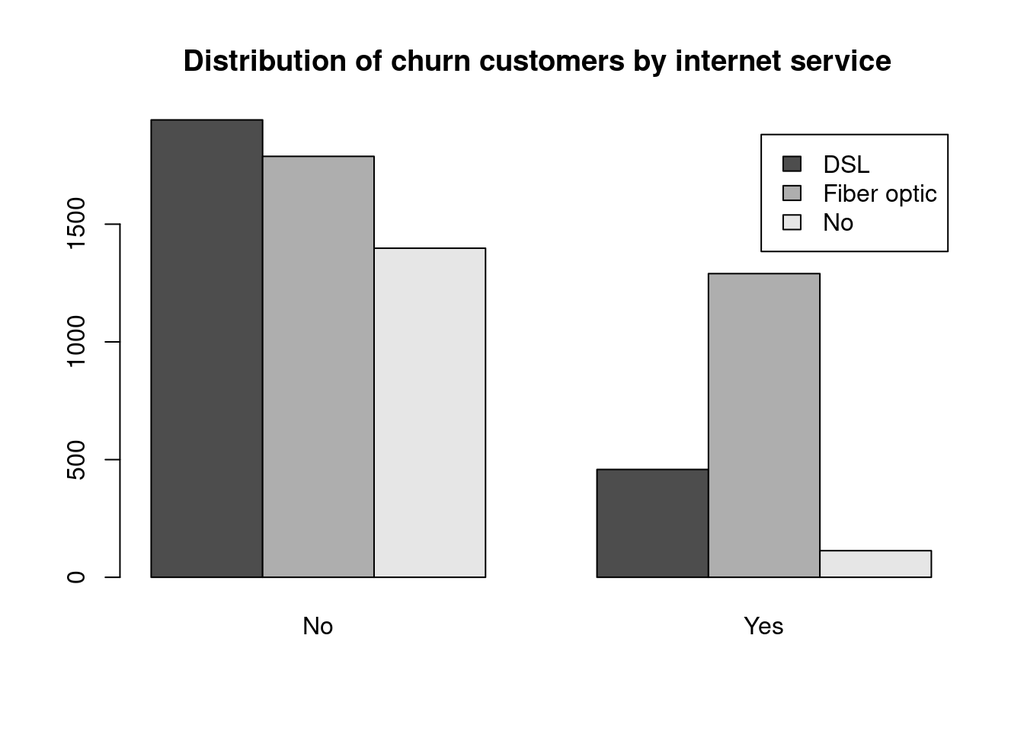

```r
tbl11 <- with(clean_df, table(internetservice, churn))

barplot(tbl11, beside = TRUE, legend = TRUE, main = "Distribution of churn customers by internet service ")
```

OBSERVATION: Among churned customers, customers on fiber optic internet service were most prevalent

#i) plotting the distribution of churn by online security and then record our observations below:

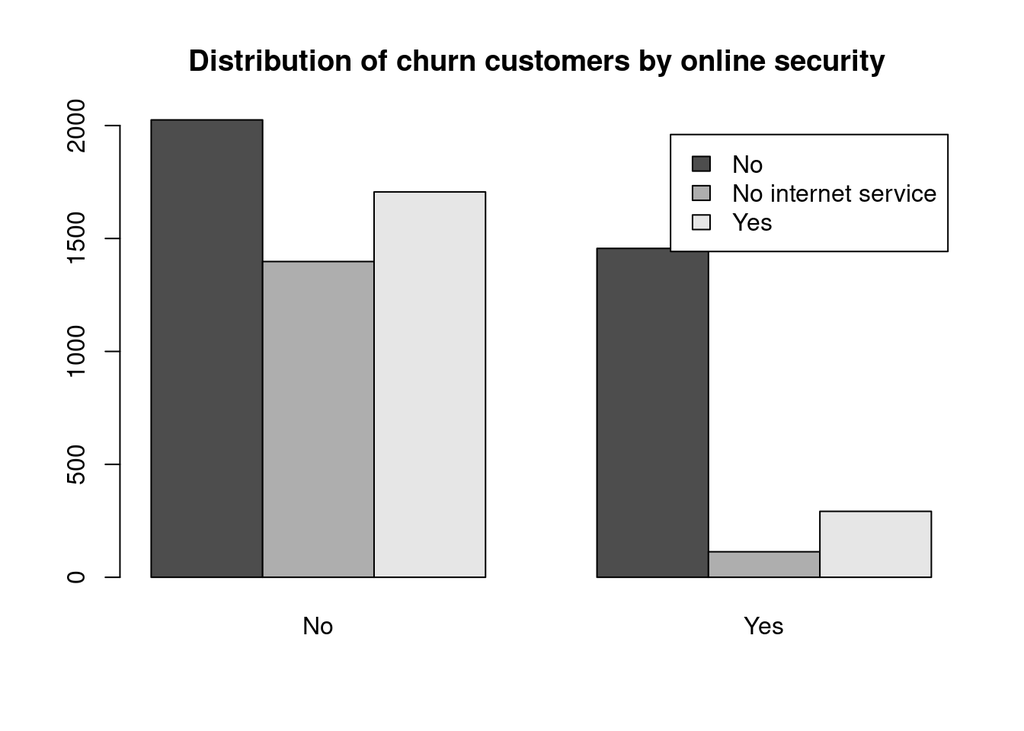

```r
tbl13 <- with(clean_df, table(onlinesecurity, churn))

barplot(tbl13, beside = TRUE, legend = TRUE, main = "Distribution of churn customers by online security ")
```

OBSERVATION:: In churned customers group, those with no online security service were the most

#j) plotting the distribution of churn by online backup

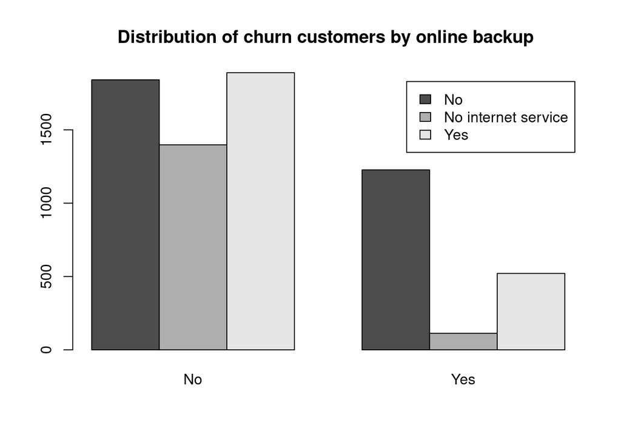

```r
tbl15 <- with(clean_df, table(onlinebackup, churn))

barplot(tbl15, beside = TRUE, legend = TRUE, main = "Distribution of churn customers by online backup ")
```

OBSERVATION:: Among churned customers, those with no online backup service were the most

#k) plotting the distribution of churn by device protection

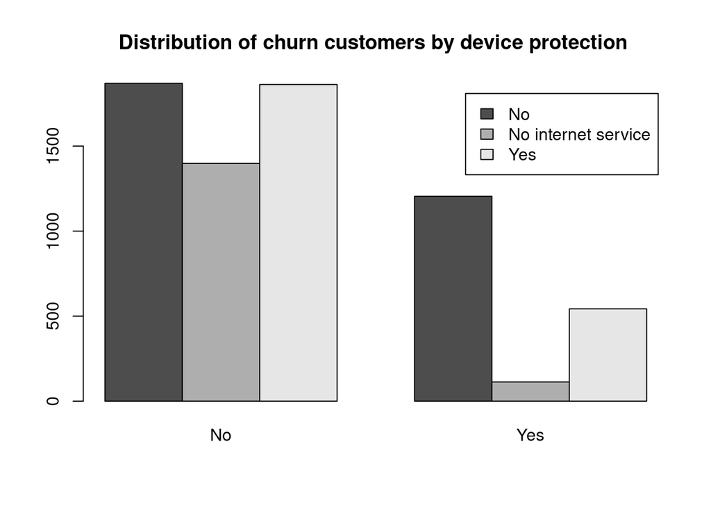

```r
tbl17 <- with(clean_df, table(deviceprotection, churn))

barplot(tbl17, beside = TRUE, legend = TRUE, main = "Distribution of churn customers by device protection ")
```

OBSERVATION::Among churned customers, those with no device protection were the most

#l) plotting the distribution of churn by tech support

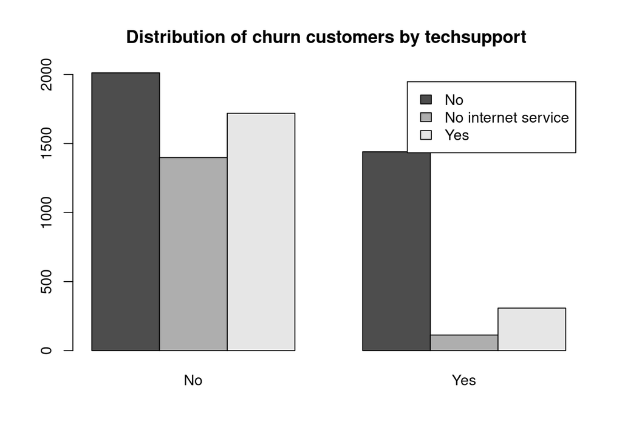

```r
tbl19 <- with(clean_df, table(techsupport, churn))

barplot(tbl19, beside = TRUE, legend = TRUE, main = "Distribution of churn customers by techsupport ")
```

OBSERVATION: Among churned customers, those with no techsupport were the most

#m) plotting the distribution of churn by streaming tv

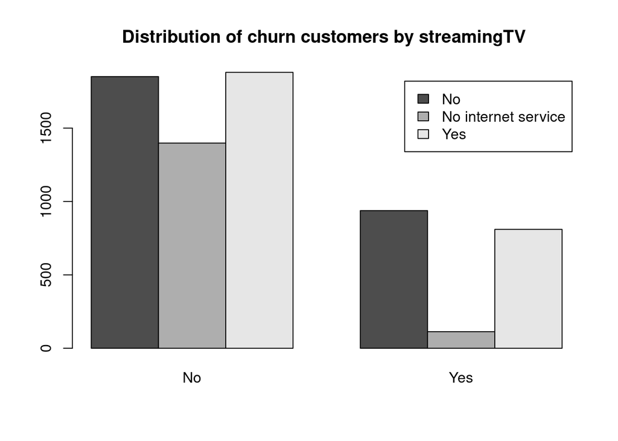

```r
tbl21 <- with(clean_df, table(streamingtv, churn))

barplot(tbl21, beside = TRUE, legend = TRUE, main = "Distribution of churn customers by streamingTV ")
```

OBSERVATION:: AMong churned customers, those with no streaming TV service were the most

#n) plotting the distribution of churn by streaming movies

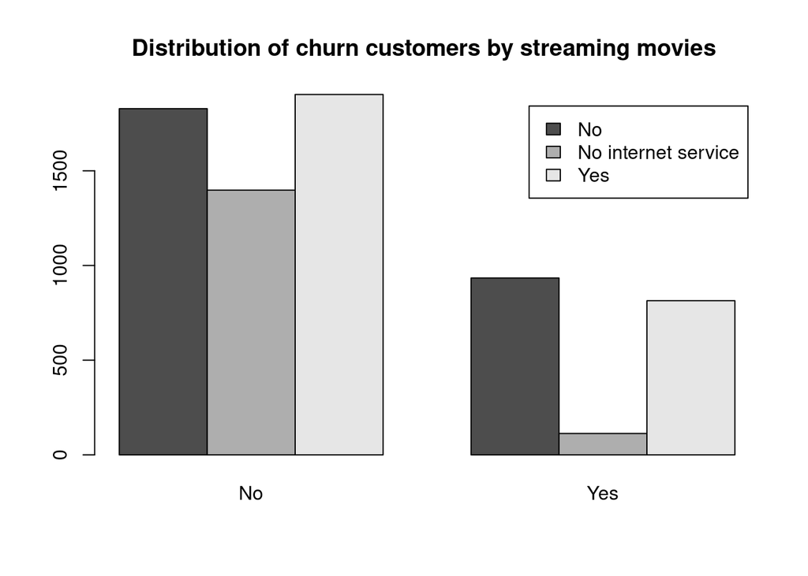

```r
tbl23 <- with(clean_df, table(streamingmovies, churn))

barplot(tbl23, beside = TRUE, legend = TRUE, main = "Distribution of churn customers by streaming movies ")
```

OBSERVATION:: Among the churned customers, those without streaming movies service were the most

#o) plotting the distribution of churn by contract

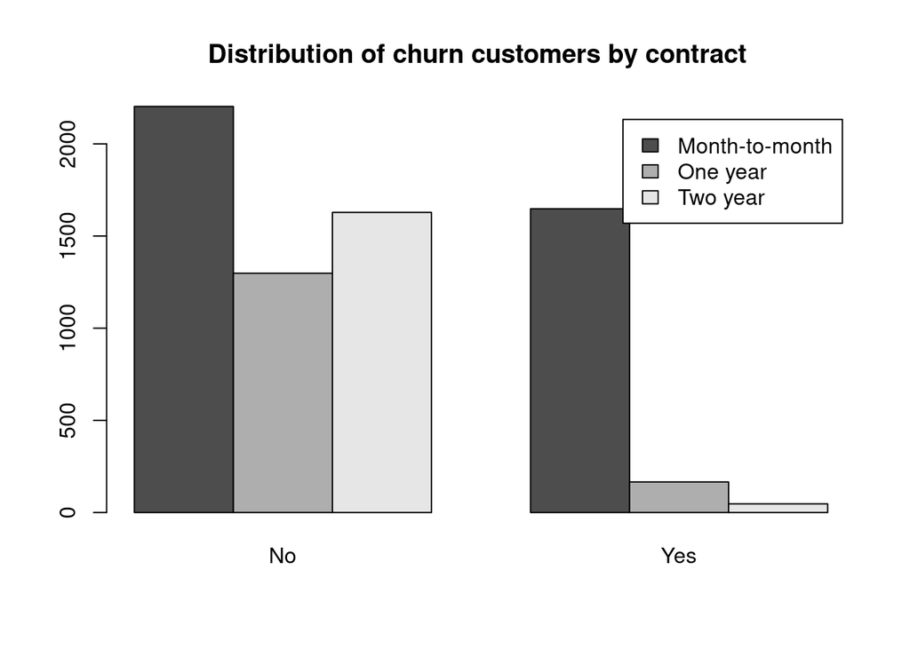

```r
tbl25 <- with(clean_df, table(contract, churn))

barplot(tbl25, beside = TRUE, legend = TRUE, main = "Distribution of churn customers by contract ")
```

OBSERVATION:: Customers on month-to-month plan are the most among churners

#p) plotting the distribution of churn by paperless billing

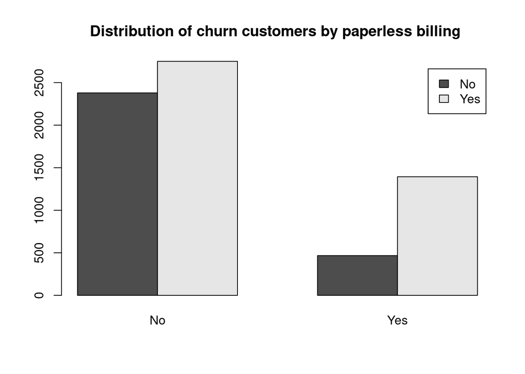

```r
tbl27 <- with(clean_df, table(paperlessbilling, churn))

barplot(tbl27, beside = TRUE, legend = TRUE, main = "Distribution of churn customers by paperless billing ")
```

OBSERVATION:: Customers on paperless billing were higher among the churned customers group

#q) plotting the distribution of churn by payment method

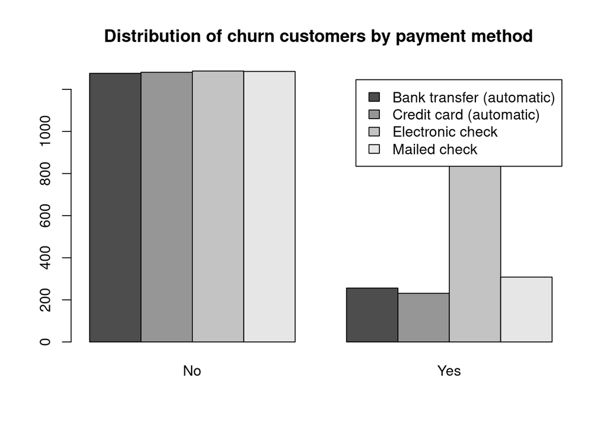

```r
tbl29 <- with(clean_df, table(paymentmethod, churn))

barplot(tbl29, beside = TRUE, legend = TRUE, main = "Distribution of churn customers by payment method ")
```

OBSERVATION:: Customers who paid via electronic check were the most in the churned group

#ii) General Analysis

#a)# previewing our data set’s gender distribution

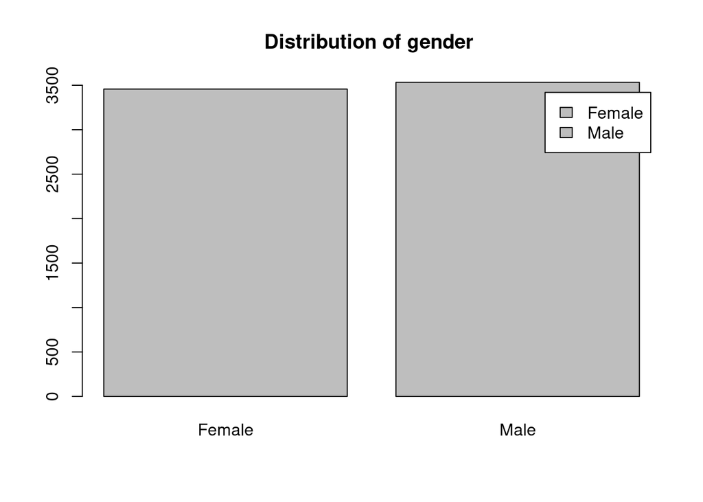

```r
tbl31 <- with(clean_df, table(gender))

barplot(tbl31, beside = TRUE, legend = TRUE, main = "Distribution of gender ")
```

We observe that the number of male and female subscribers is almost the same.

#b) plotting distribution of senior citizens

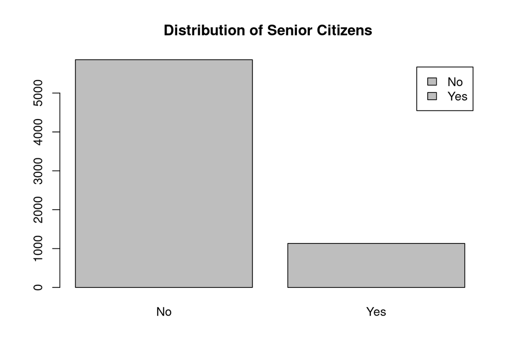

```r
tbl32 <- with(clean_df, table(seniorcitizen))

barplot(tbl32, beside = TRUE, legend = TRUE, main = "Distribution of Senior Citizens ")
```

We observe the following - few subscribers are senior citizens

#c) Plotting a distribution of subscribers with partners and those without

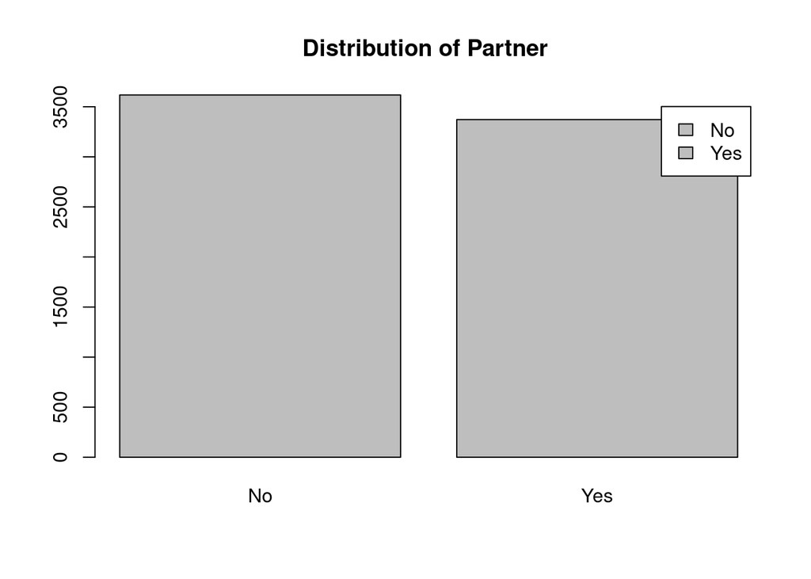

```r
tbl33 <- with(clean_df, table(partner))

barplot(tbl33, beside = TRUE, legend = TRUE, main = "Distribution of Partner ")
```

OBSERVATION::Customers without partner are slightly more than those with partners

#d) plotting a distribution of customers with dependents and those without

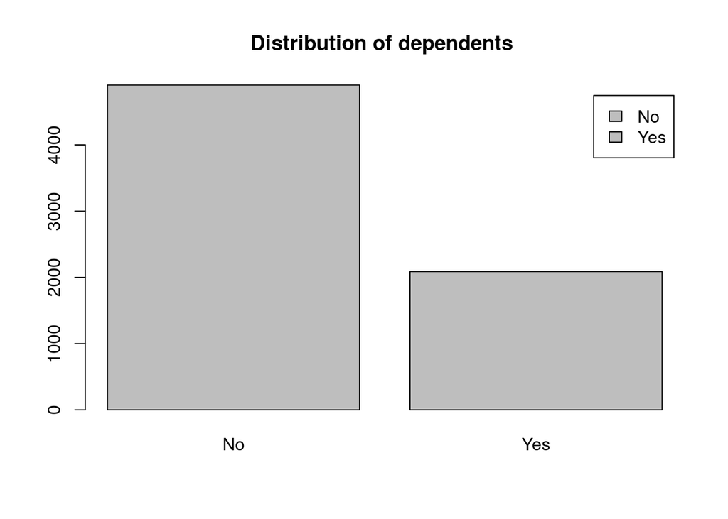

```r
tbl34 <- with(clean_df, table(dependents))

barplot(tbl34, beside = TRUE, legend = TRUE, main = "Distribution of dependents ")
```

OBSERVATION:: Majority of the subscribers do not have dependents.

#e) Plotting a distribution by tenure

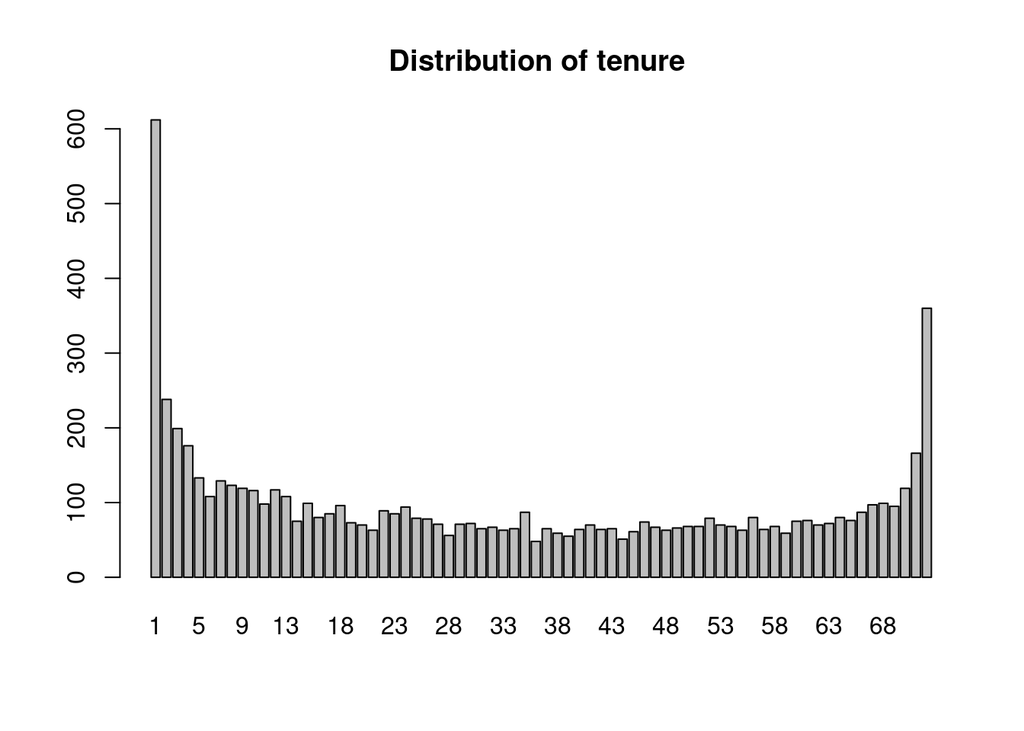

```r
tbl35 <- with(clean_df, table(tenure))

barplot(tbl35, beside = TRUE, main = "Distribution of tenure ")
```

OBSERVATION:: We observe that the majority have tenure of 1-5 followed by those with tenure between 67-72.

#f) plotting distribution of phone service

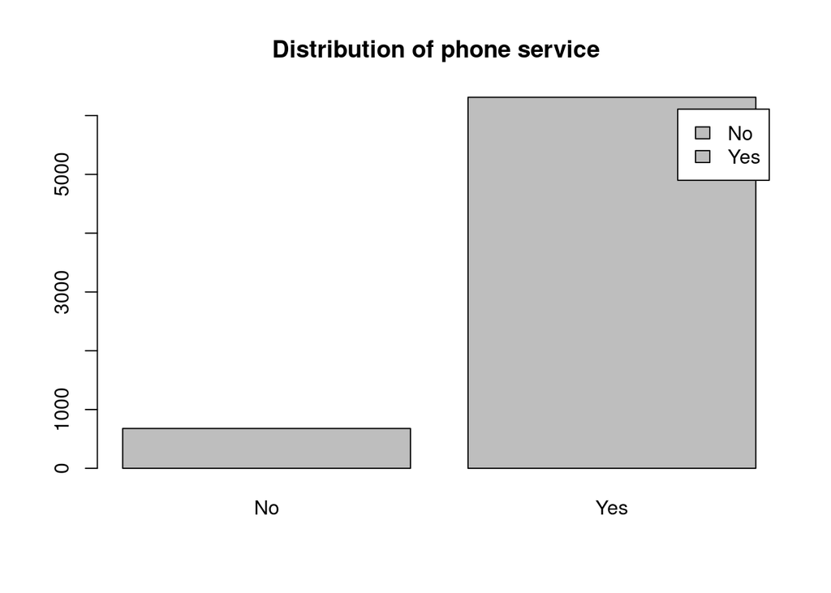

```r
tbl36 <- with(clean_df, table(phoneservice))

barplot(tbl36, beside = TRUE, legend = TRUE, main = "Distribution of phone service ")
```

OBSERVATION::Majority of customer base has an active phone service

#g) Plotting a distribution of multiple lines

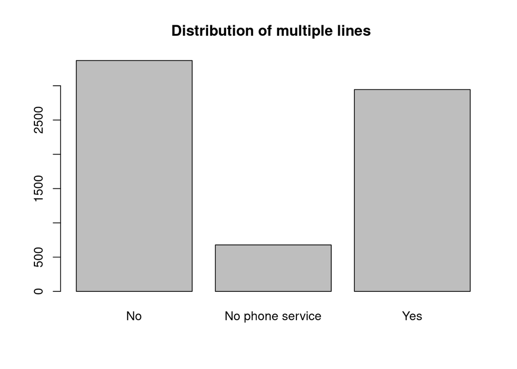

```r
tbl37 <- with(clean_df, table(multiplelines))

barplot(tbl37, beside = TRUE, main = "Distribution of multiple lines ")
```

OBSERVATION::Customers without multiple lines are the highest group

#h) plotting distribution of internet service

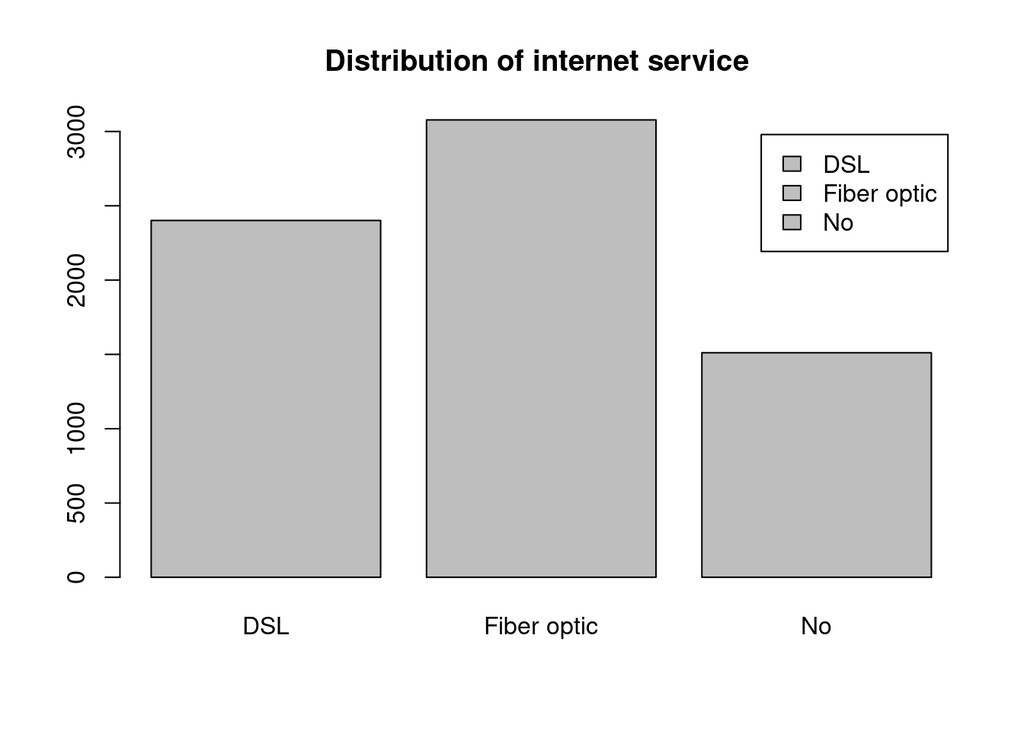

```r
tbl38 <- with(clean_df, table(internetservice))

barplot(tbl38, beside = TRUE, legend = TRUE, main = "Distribution of internet service ")
```

OBSERVATION:: We observe the following: Many have fiber optic, about three quarters of the same number have DSL, and roughly half of that number do not have internet service.

#i) plotting a distribution of online security

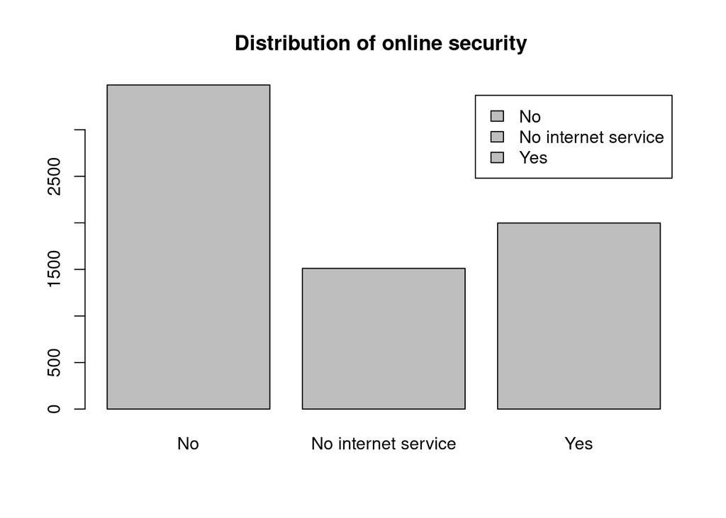

```r
tbl39 <- with(clean_df, table(onlinesecurity))

barplot(tbl39, beside = TRUE, legend = TRUE, main = "Distribution of online security ")
```

OBSERVATION:: Majority of the subscribers do not have online security while half of that number has. Fewer still have online security but no internet service.

#j) plotting distribution of online backup

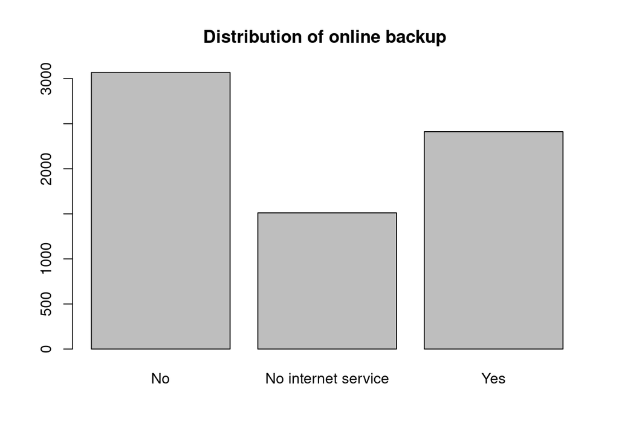

```r
tbl40 <- with(clean_df, table(onlinebackup))

barplot(tbl40, beside = TRUE, main = "Distribution of online backup ")
```

#k) plotting distribution of device protection

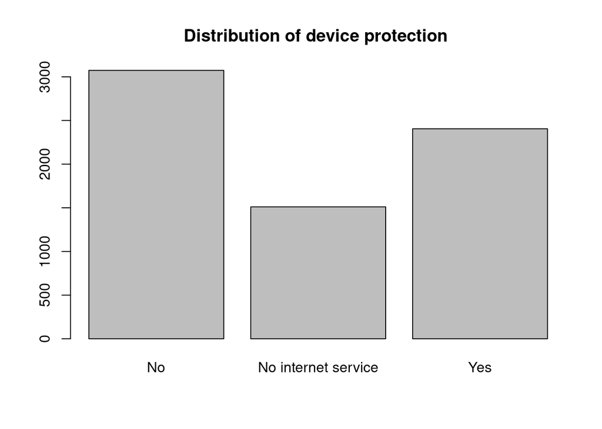

```r
tbl41 <- with(clean_df, table(deviceprotection))

barplot(tbl41, beside = TRUE, main = "Distribution of device protection ")
```

OBSERVATION::Majority do not have device protection.